# Project1-Group2

Emma Zhang, Ricky Wong, Xiaoxin Bian

2024-06-16

## Objective

The goal of this project is to conduct a sentiment analysis of popular keywords and phrases across Twitter, Instagram, and Facebook. This analysis aims to uncover and understand public opinions and emotions, providing actionable insights that enable Ignite Digital, a digital marketing agency, to refine their strategies and enhance their service offerings.

## Install required libraries

## Load the dataset

```r
df <- read.csv("./sentimentdataset.csv")
```

**Use glimpse to explore the dataset.**

```r
glimpse(df)
```

```
## Rows: 732
## Columns: 15
## $ X          <int> 0, 1, 2, 3, 4, 5, 6, 7, 8, 9, 10, 11, 12, 13, 14, 15, 16, 1…
## $ Unnamed..0 <int> 0, 1, 2, 3, 4, 5, 6, 7, 8, 9, 10, 11, 12, 13, 14, 15, 16, 1…
## $ Text       <chr> " Enjoying a beautiful day at the park!              ", " T…
## $ Sentiment  <chr> " Positive  ", " Negative  ", " Positive  ", " Positive  ",…
## $ Timestamp  <chr> "2023-01-15 12:30:00", "2023-01-15 08:45:00", "2023-01-15 1…
## $ User       <chr> " User123      ", " CommuterX    ", " FitnessFan   ", " Adv…
## $ Platform   <chr> " Twitter  ", " Twitter  ", " Instagram ", " Facebook ", " …
## $ Hashtags   <chr> " #Nature #Park                            ", " #Traffic #M…
## $ Retweets   <dbl> 15, 5, 20, 8, 12, 25, 10, 15, 30, 18, 22, 7, 12, 28, 15, 20…
## $ Likes      <dbl> 30, 10, 40, 15, 25, 50, 20, 30, 60, 35, 45, 15, 25, 55, 30,…
## $ Country    <chr> " USA      ", " Canada   ", " USA        ", " UK       ", "…
## $ Year       <int> 2023, 2023, 2023, 2023, 2023, 2023, 2023, 2023, 2023, 2023,…
## $ Month      <int> 1, 1, 1, 1, 1, 1, 1, 1, 1, 1, 1, 1, 1, 1, 1, 1, 1, 1, 1, 1,…
## $ Day        <int> 15, 15, 15, 15, 15, 16, 16, 16, 17, 17, 17, 18, 18, 18, 19,…
## $ Hour       <int> 12, 8, 15, 18, 19, 9, 14, 19, 8, 12, 15, 10, 14, 18, 9, 13,…
```

## Data Processing

**Remove unnecessary columns**

```r
df <- df[, -c(1, 2)]
df$Country <- as.factor(str_trim(df$Country))
```

**Define sentiment label categories**

```r
positive <- c("Positive", "Happiness", "Joy", "Love", "Amusement", "Enjoyment", "Admiration", "Affection", "Awe","Acceptance", "Adoration", "Calmness", "Excitement", "Kind", "Pride", "Elation", "Euphoria", "Contentment", "Serenity", "Gratitude", "Hope", "Empowerment", "Compassion", "Tenderness", "Enthusiasm", "Fulfillment", "Reverence", "Hopeful", "Proud", "Grateful", "Empathetic", "Compassionate", "Playful", "Free-spirited", "Inspired", "Confident", "Thrill", "Overjoyed", "Inspiration", "Motivation", "JoyfulReunion","Satisfaction", "Blessed", "Appreciation", "Confidence", "Accomplishment", "Wonderment", "Optimism", "Enchantment", "Mindfulness", "Elegance", "Whimsy", "Harmony", "Creativity", "Radiance", "Wonder", "Rejuvenation", "Coziness", "Adventure", "Melodic", "FestiveJoy", "InnerJourney", "Freedom", "Dazzle", "Adrenaline", "ArtisticBurst", "CulinaryOdyssey", "Resilience", "Immersion", "Spark", "Marvel", "Positivity", "Kindness", "Friendship", "Success", "Exploration", "Amazement", "Romance", "Captivation", "Tranquility", "Grandeur", "Emotion", "Energy", "Celebration", "Charm", "Ecstasy", "Colorful", "Hypnotic", "Connection", "Iconic", "Journey", "Engagement", "Touched", "Triumph", "Heartwarming", "Solace", "Breakthrough", "Imagination", "Vibrancy", "Mesmerizing", "Creative Inspiration", "Nature's Beauty", "Celestial Wonder", "Happy", "PlayfulJoy", "DreamChaser", "Blessing", "Sympathy", "Renewed Effort", "Culinary Adventure", "Determination", "Zest", "Joy in Baking", "Challenge", "Winter Magic", "Thrilling Journey", "Runway Creativity", "Ocean's Freedom", "Relief", "Curiosity"
)

negative <- c("Negative", "Anger", "Fear", "Sadness", "Disgust", "Disappointed", "Bitter", "Shame", "Despair", "Grief", "Loneliness", "Jealousy", "Resentment", "Frustration", "Boredom", "Anxiety", "Intimidation", "Helplessness", "Envy", "Regret", "Melancholy", "Fearful", "Apprehensive", "Overwhelmed", "Devastated", "Frustrated", "Envious", "Dismissive", "Bitterness", "Heartbreak", "Betrayal", "Suffering", "EmotionalStorm", "Isolation", "Disappointment", "LostLove", "Exhaustion", "Sorrow", "Darkness", "Desperation", "Ruins", "Desolation", "Loss", "Heartache", "Solitude", "Obstacle", "Pressure", "Miscalculation", "Sad", "Hate", "Bad", "Jealous", "Embarrassed"
)

neutral <- c("Neutral", "Surprise", "Anticipation", "Confusion", "Arousal", "Indifference", "Numbness", "Nostalgia", "Ambivalence",  "Contemplation", "Reflection", "Intrigue", "Whispers of the Past", "Pensive", "Bittersweet", "Suspense", "Envisioning History", "Mischievous", "Yearning"
)
```

**Add a label column based on category definition**

```r
df <- df %>% mutate(
  Sentiment = trimws(Sentiment),
  Sentiment_Label = case_when(
  Sentiment %in% positive ~ "Positive",
  Sentiment %in% negative ~ "Negative",
  Sentiment %in% neutral ~ "Neutral"
))
```

**View processed data*

```r
head(df)
```

```
##                                                   Text Sentiment
## 1  Enjoying a beautiful day at the park!                Positive
## 2  Traffic was terrible this morning.                   Negative
## 3   Just finished an amazing workout! 💪                 Positive
## 4  Excited about the upcoming weekend getaway!          Positive
## 5  Trying out a new recipe for dinner tonight.           Neutral
## 6  Feeling grateful for the little things in life.      Positive
##             Timestamp           User    Platform
## 1 2023-01-15 12:30:00  User123         Twitter
## 2 2023-01-15 08:45:00  CommuterX       Twitter
## 3 2023-01-15 15:45:00  FitnessFan     Instagram
## 4 2023-01-15 18:20:00  AdventureX      Facebook
## 5 2023-01-15 19:55:00  ChefCook       Instagram
## 6 2023-01-16 09:10:00  GratitudeNow    Twitter
##                                     Hashtags Retweets Likes   Country Year
## 1  #Nature #Park                                   15    30       USA 2023
## 2  #Traffic #Morning                                5    10    Canada 2023
## 3  #Fitness #Workout                               20    40       USA 2023
## 4  #Travel #Adventure                               8    15        UK 2023
## 5  #Cooking #Food                                  12    25 Australia 2023
## 6    #Gratitude #PositiveVibes                     25    50     India 2023
##   Month Day Hour Sentiment_Label
## 1     1  15   12        Positive
## 2     1  15    8        Negative
## 3     1  15   15        Positive
## 4     1  15   18        Positive
## 5     1  15   19         Neutral
## 6     1  16    9        Positive
```

**Sentiment distribution by platform*

```r
sentiment_platform <- df %>%
  mutate(Platform = trimws(Platform)) %>%
  group_by(Platform, Sentiment_Label) %>%
  summarise(Count = n())
sentiment_platform
```

```
## # A tibble: 9 × 3
## # Groups:   Platform [3]
##   Platform  Sentiment_Label Count
##   <chr>     <chr>           <int>
## 1 Facebook  Negative           56
## 2 Facebook  Neutral            22
## 3 Facebook  Positive          153
## 4 Instagram Negative           60
## 5 Instagram Neutral            34
## 6 Instagram Positive          164
## 7 Twitter   Negative           64
## 8 Twitter   Neutral            28
## 9 Twitter   Positive          151
```

```r
# Extract hashtags from the Hashtags column
extract_hashtags <- function(hashtags) {
  unlist(strsplit(hashtags, " "))
}

all_hashtags <- unlist(lapply(df$Hashtags, extract_hashtags))
all_hashtags <- all_hashtags[all_hashtags != "" & all_hashtags != " "]
hashtag_counts <- as.data.frame(table(all_hashtags))

colnames(hashtag_counts) <- c("Hashtag", "Frequency")
sorted_hashtag_counts <- hashtag_counts %>%
  arrange(desc(Frequency))

sorted_hashtag_counts
```

```
##                          Hashtag Frequency
## 1                      #Serenity        15
## 2                    #Excitement        13
## 3                     #Gratitude        13
## 4                       #Despair        11
## 5                     #Nostalgia        11
## 6                   #Contentment        10
## 7                     #Curiosity        10
## 8                           #Awe         9
## 9                         #Grief         9
## 10                      #Hopeful         9
## 11                   #Loneliness         9
## 12                   #Acceptance         8
## 13                    #Confusion         8
## 14                   #Enthusiasm         8
```

[output cut: 961 more lines]

## Question 1: What are the prevailing sentiments associated with key marketing terms and how do they vary across different social media platforms?

Authored by: Emma Zhang

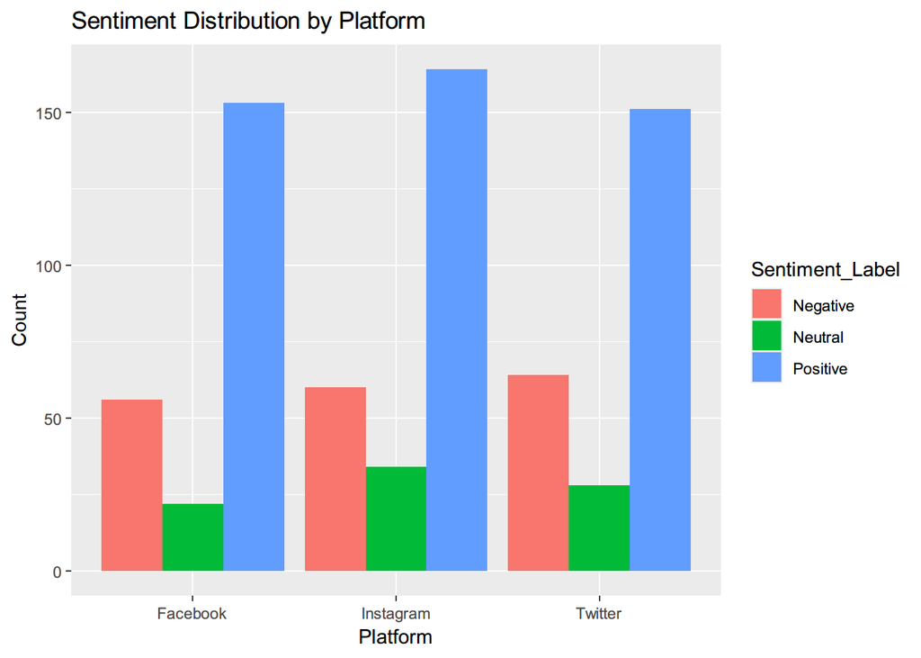

```r
library(ggplot2)
ggplot(sentiment_platform, aes(x = trimws(Platform), y = Count, fill = Sentiment_Label)) +
  geom_bar(stat = "identity", position = "dodge") +
  labs(title = "Sentiment Distribution by Platform", x = "Platform", y = "Count")
```

## Question 2: How do public sentiments correlate with variations in engagement metrics like likes and retweets?

Authored by: Emma Zhang

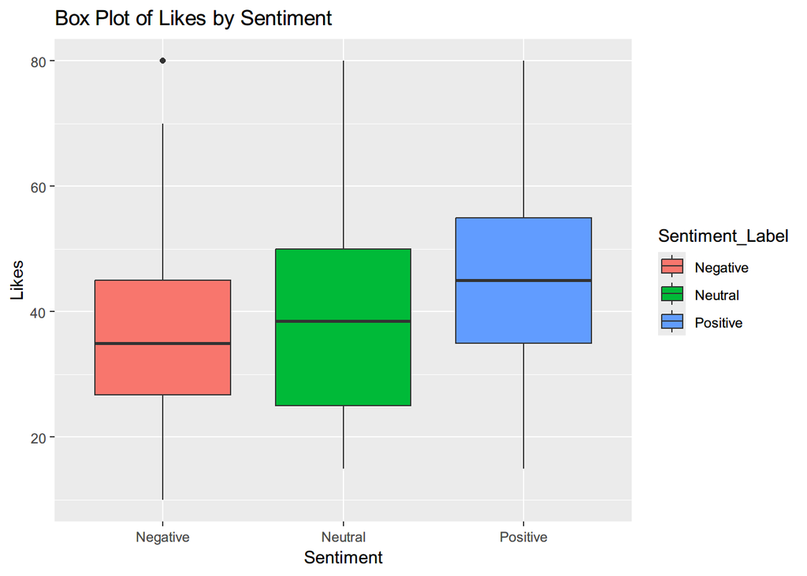

```r
ggplot(df, aes(x = Sentiment_Label, y = Likes, fill = Sentiment_Label)) +
  geom_boxplot() +
  labs(title = "Box Plot of Likes by Sentiment", x = "Sentiment", y = "Likes")
```

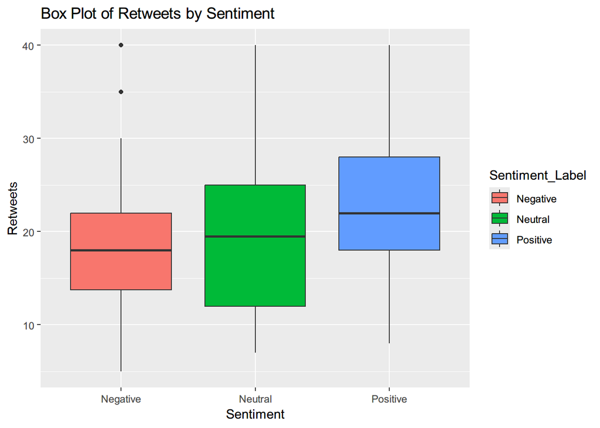

```r
ggplot(df, aes(x = Sentiment_Label, y = Retweets, fill = Sentiment_Label)) +
  geom_boxplot() +
  labs(title = "Box Plot of Retweets by Sentiment", x = "Sentiment", y = "Retweets")
```

Authored by: Ricky Wong

In marketing trend investigations, understanding regional differences in user-generated content is crucial for tailoring strategies to specific markets. Social media users come from diverse regions, and analyzing sentiment and engagement metrics across these regions helps us optimize our marketing efforts.

By examining our dataset, which categorizes user-generated content by sentiment (positive, negative, neutral) and includes engagement metrics like likes and retweets, we can identify regional trends. This analysis focuses on North America and Europe to highlight key differences.

Analysis Strategy: 1. We grouped the data by country and sentiment to observe variations. We focused on the top 10 countries by post count, calculating the percentage of each sentiment. 2. We want to focus in North America and Europe, we grouped the top 10 countries into North America and Europe. We then again analyze sentiment distribution within these regions. 3. For each region, identify the top 10 hashtags based on the total number of retweets from posts containing these hashtags.

```r
sentiment_by_region <- df %>%
  group_by(Country, Sentiment_Label) %>%
  summarize(count = n()) %>%
  ungroup()
top_countries <- sentiment_by_region %>%
  group_by(Country) %>%
  summarize(total_count = sum(count)) %>%
  top_n(10, total_count) %>%
  pull(Country)

top_sentiment_by_region <- sentiment_by_region %>%
  filter(Country %in% top_countries)

top_sentiment_by_region <- top_sentiment_by_region %>%
  group_by(Country) %>%
  mutate(percentage = count / sum(count) * 100) %>%
  ungroup()

top_sentiment_by_region <- top_sentiment_by_region %>%
  left_join(
    sentiment_by_region %>%
      group_by(Country) %>%
      summarize(total_count = sum(count)),
    by = "Country"
  )

top_sentiment_by_region
```

```
## # A tibble: 29 × 5
##    Country   Sentiment_Label count percentage total_count
##    <fct>     <chr>           <int>      <dbl>       <int>
##  1 Australia Negative           19       25.3          75
##  2 Australia Neutral            14       18.7          75
##  3 Australia Positive           42       56            75
##  4 Brazil    Negative            6       35.3          17
##  5 Brazil    Positive           11       64.7          17
##  6 Canada    Negative           36       26.7         135
##  7 Canada    Neutral            14       10.4         135
##  8 Canada    Positive           85       63.0         135
##  9 France    Negative            6       37.5          16
## 10 France    Neutral             2       12.5          16
## # ℹ 19 more rows
```

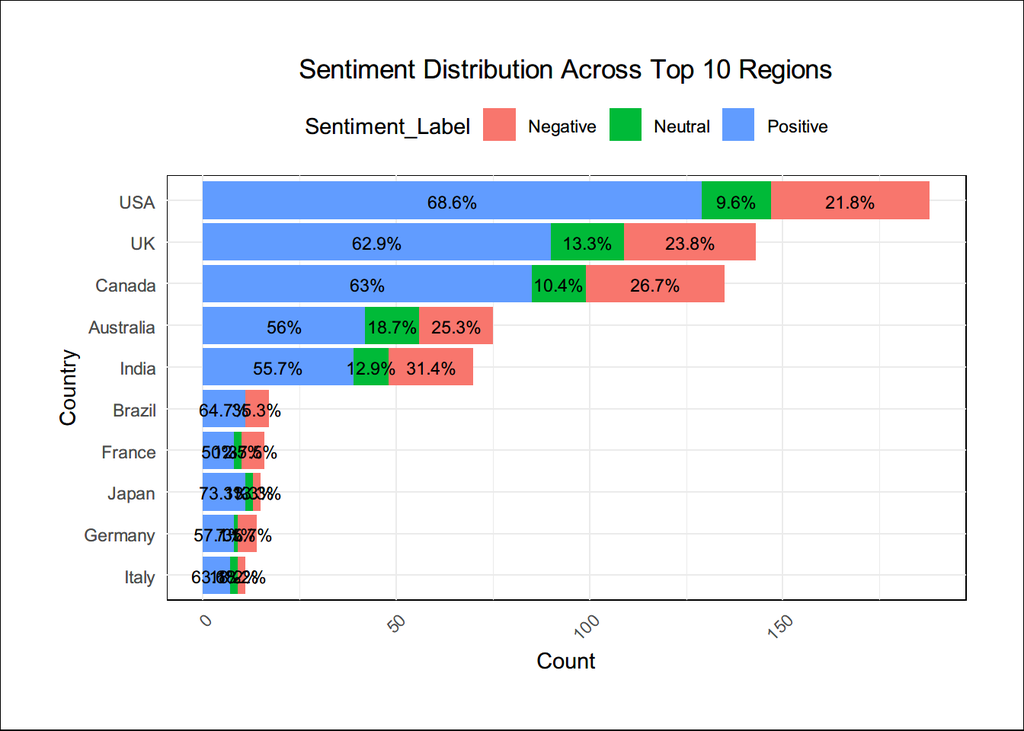

```r
p1 <- ggplot(top_sentiment_by_region, aes(x = reorder(Country, total_count), y = count, fill = Sentiment_Label)) +
  geom_bar(stat = "identity", position = "stack") +
  geom_text(aes(label = paste0(round(percentage, 1), "%")),
            position = position_stack(vjust = 0.5), size = 3) +
  ggtitle("Sentiment Distribution Across Top 10 Regions") +
  theme_minimal() +
  xlab("Country") +
  ylab("Count") +
  theme(axis.text.x = element_text(angle = 45, hjust = 1),
        plot.title = element_text(hjust = 0.5),
        legend.position = "top") +
  theme(plot.margin = margin(5, 5, 5, 5),
        plot.background = element_rect(fill = "white"),
        panel.background = element_rect(fill = "white")) +
  theme(plot.margin = unit(c(1, 1, 1, 1), "cm")) +
  coord_flip() +
  theme(plot.background = element_rect(fill = "white"),
        panel.background = element_rect(fill = "white")) +
  theme(plot.margin = unit(c(1, 1, 1, 1), "cm"))

p1
```

```r
# ggsave("./charts/sentiment_distribution_across_regions.png", p1, height = 15, width =25)
```

### Results 1:

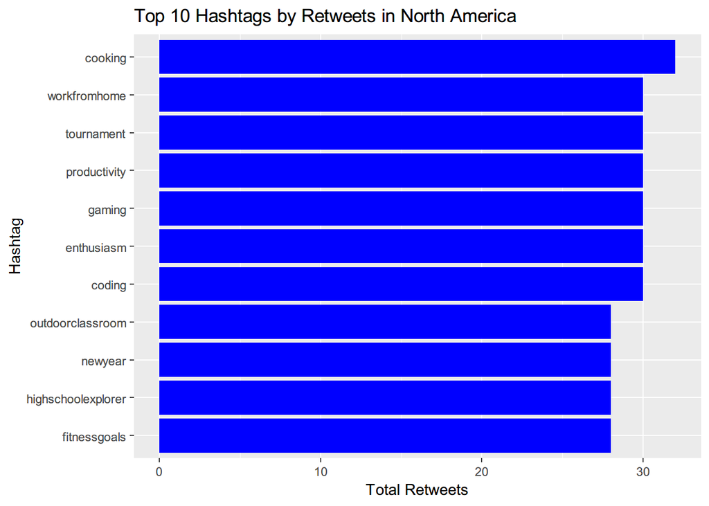

```r
north_america <- c("USA", "Canada")
europe <- c("UK", "Germany", "France", "Italy")

df_na <- df %>% filter(Country %in% north_america)
df_eu <- df %>% filter(Country %in% europe)

# Top 10 hashtags by retweets in North America
top_hashtags_na <- df_na %>%
  filter(Sentiment == "Positive") %>%
  unnest_tokens(word, Hashtags) %>%
  group_by(word) %>%
  summarize(total_retweets = sum(Retweets)) %>%
  top_n(10, total_retweets)

# Top 10 hashtags by retweets in Europe
top_hashtags_eu <- df_eu %>%
  filter(Sentiment == "Positive") %>%
  unnest_tokens(word, Hashtags) %>%
  group_by(word) %>%
  summarize(total_retweets = sum(Retweets)) %>%
  top_n(10, total_retweets)

# Plot top hashtags by retweets for North America
p2 <- ggplot(top_hashtags_na, aes(x = reorder(word, total_retweets), y = total_retweets)) +
  geom_bar(stat = "identity", fill = "blue") +
  coord_flip() +
  ggtitle("Top 10 Hashtags by Retweets in North America") +
  xlab("Hashtag") +
  ylab("Total Retweets")

print(p2)
```

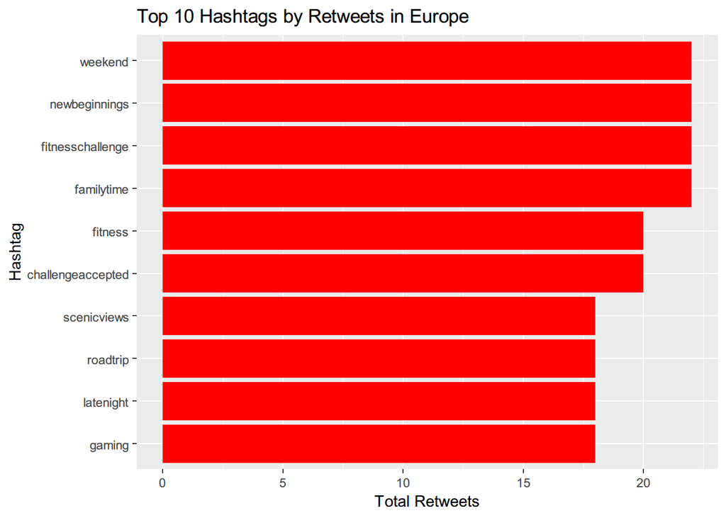

```r
# Plot top hashtags by retweets for Europe
p3 <- ggplot(top_hashtags_eu, aes(x = reorder(word, total_retweets), y = total_retweets)) +
  geom_bar(stat = "identity", fill = "red") +
  coord_flip() +
  ggtitle("Top 10 Hashtags by Retweets in Europe") +
  xlab("Hashtag") +
  ylab("Total Retweets")

print(p3)
```

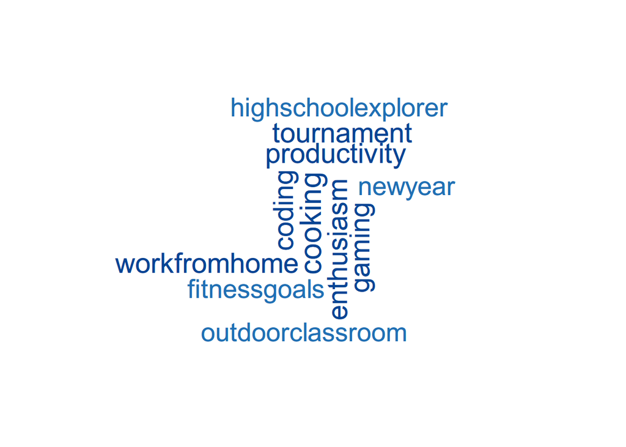

```r
# Select top 3 hashtags from the top 10

# Create word clouds for top 3 hashtags
wordcloud(words = top_hashtags_na$word, freq = top_hashtags_na$total_retweets,
          scale = c(2, 0.1), min.freq = 1,
          max.words = 200,
          random.order = FALSE,
          rot.per = 0.35,colors = brewer.pal(8, "Blues"), main = "Top 3 Hashtags in North America")
```

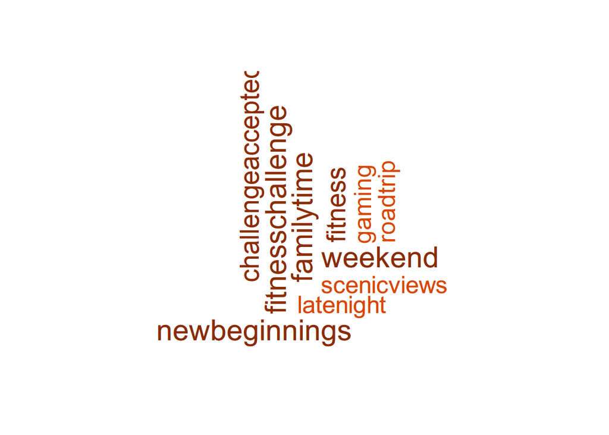

```r
wordcloud(words = top_hashtags_eu$word, freq = top_hashtags_eu$total_retweets,
          scale = c(2, 0.1), min.freq = 1,
          max.words = 200,
          random.order = FALSE,
          rot.per = 0.35,colors = brewer.pal(8, "Oranges"), main = "Top 3 Hashtags in Europe")
```

### Results 2:

We aggregated the data according to the countries belonging to North America and Europe and further analyzed it. We identified the top 10 hashtags by retweets in both regions. For North America, the top hashtags are #cooking, #workfromhome, #productivity, #coding, and so on. For Europe, the leading hashtags are #fitnesschallenge, #familytime, #weekend, and #newbeginnings.

## Question 6: How do the sentiments associated with key marketing terms change over time? Which months have the highest counts of positive and negative sentiments, and what are the trending hashtags during these periods? [Time-specifc strategy]

Authored by: Ricky Wong

```r
df$Timestamp <- as.POSIXct(df$Timestamp, format="%Y-%m-%d %H:%M:%S")

# Extract year and month for time series analysis
df <- df %>%
  mutate(YearMonth = format(Timestamp, "%Y-%m"))

# Filter data to include only from 2020 onward
df <- df %>%
  filter(format(Timestamp, "%Y") >= 2020)

# Group by YearMonth and Sentiment to get the count of each sentiment per month
sentiment_over_time <- df %>%
  group_by(YearMonth, Sentiment_Label) %>%
  summarize(count = n()) %>%
  ungroup()
sentiment_over_time
```

```
## # A tibble: 103 × 3
##    YearMonth Sentiment_Label count
##    <chr>     <chr>           <int>
##  1 2020-01   Negative            1
##  2 2020-01   Positive            5
##  3 2020-02   Negative            1
##  4 2020-02   Positive            3
##  5 2020-03   Negative            1
##  6 2020-03   Neutral             1
##  7 2020-03   Positive            1
##  8 2020-04   Negative            2
##  9 2020-04   Neutral             2
## 10 2020-04   Positive            5
## # ℹ 93 more rows
```

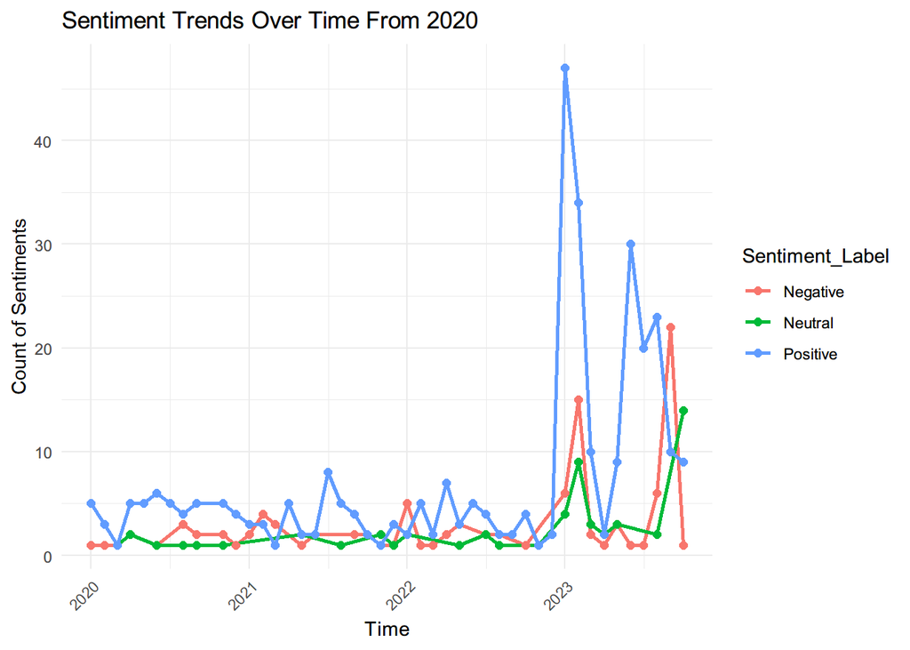

```r
# Plot the sentiment trends over time
ggplot(sentiment_over_time, aes(x = as.Date(paste0(YearMonth, "-01")), y = count, color = Sentiment_Label)) +
  geom_line(size = 1) +
  geom_point(size = 2) +
  ggtitle("Sentiment Trends Over Time From 2020") +
  xlab("Time") +
  ylab("Count of Sentiments") +
  theme_minimal() +
  theme(axis.text.x = element_text(angle = 45, hjust = 1))
```

```r
max_positive_month <- sentiment_over_time %>%
  filter(Sentiment_Label == "Positive") %>%
  arrange(desc(count)) %>%
  slice(1) %>%
  pull(YearMonth)

max_negative_month <- sentiment_over_time %>%
  filter(Sentiment_Label == "Negative") %>%
  arrange(desc(count)) %>%
  slice(1) %>%
  pull(YearMonth)

positive_month_data <- df %>%
  filter(YearMonth == max_positive_month)

negative_month_data <- df %>%
  filter(YearMonth == max_negative_month)

top_positive_hashtags <- positive_month_data %>%
  unnest_tokens(word, Hashtags) %>%
  group_by(word) %>%
  summarize(post_count = n()) %>%
  arrange(desc(post_count))

top_negative_hashtags <- negative_month_data %>%
  unnest_tokens(word, Hashtags) %>%
  group_by(word) %>%
  summarize(post_count = n()) %>%
  arrange(desc(post_count))

top_positive_hashtags
```

```
## # A tibble: 105 × 2
##    word           post_count
##    <chr>               <int>
##  1 cooking                 3
##  2 art                     2
##  3 fitness                 2
##  4 gaming                  2
##  5 nature                  2
##  6 reading                 2
##  7 reflection              2
##  8 virtualreality          2
##  9 acceptance              1
## 10 accomplished            1
## # ℹ 95 more rows
```

```r
top_negative_hashtags
```

```
## # A tibble: 58 × 2
##    word                post_count
##    <chr>                    <int>
##  1 highschoolstruggles          3
##  2 empathetic                   2
##  3 highschoolemotions           2
##  4 highschoolreality            2
##  5 lanternofcompassion          2
##  6 academicfrustration          1
##  7 badday                       1
##  8 badhairday                   1
##  9 badluck                      1
## 10 badluckday                   1
## # ℹ 48 more rows
```

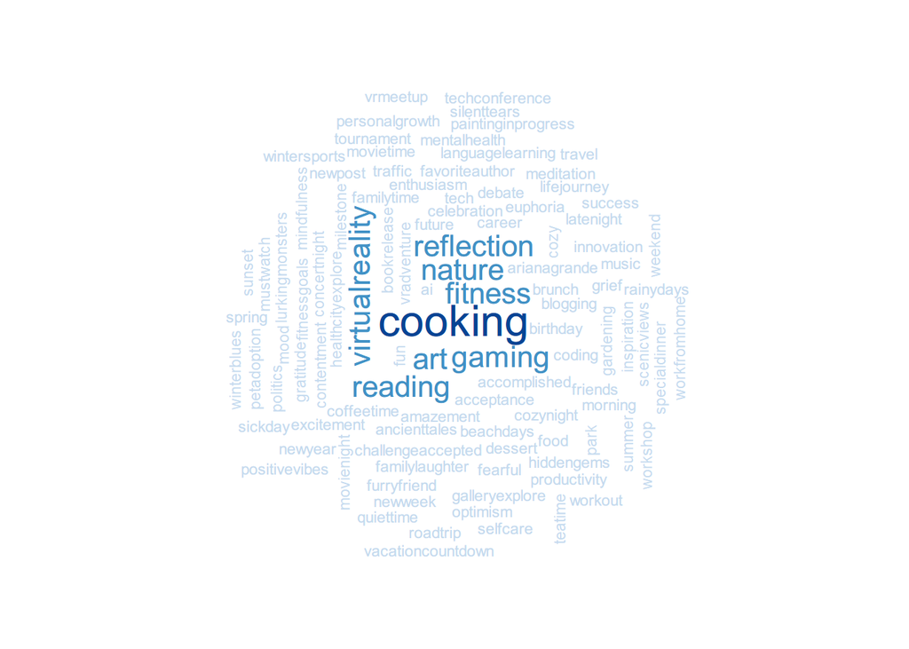

```r
wordcloud(words = top_positive_hashtags$word, freq = top_positive_hashtags$post_count,
          scale = c(2, 0.1), min.freq = 1,
          max.words = 200,
          random.order = FALSE,
          rot.per = 0.35, colors = brewer.pal(8, "Blues"), main = paste("Top Hashtags in", max_positive_month, "(Positive)"))
```

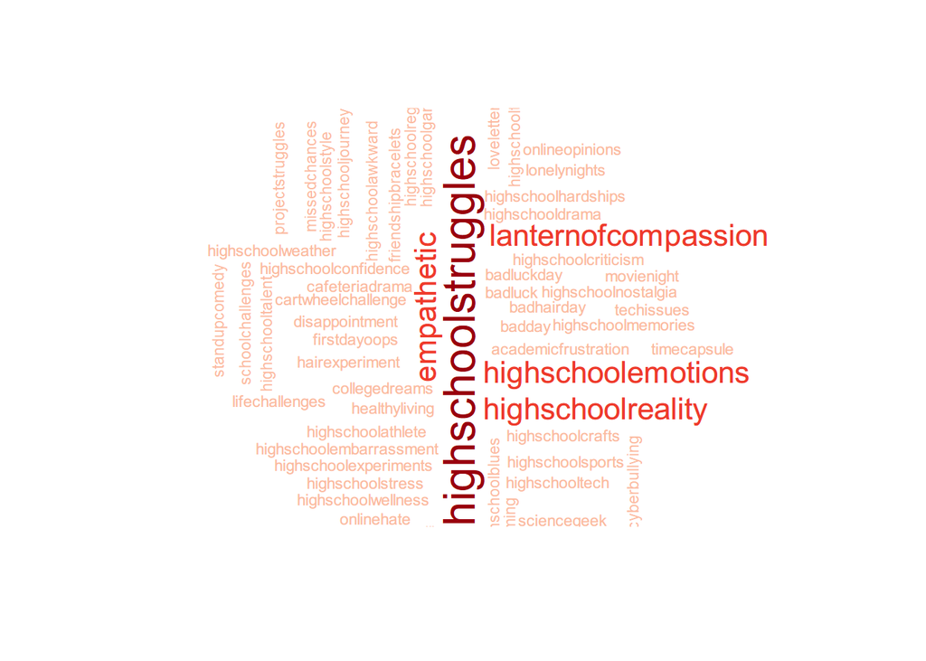

```r
wordcloud(words = top_negative_hashtags$word, freq = top_negative_hashtags$post_count,
          scale = c(2, 0.1), min.freq = 1,
          max.words = 200,
          random.order = FALSE,
          rot.per = 0.35, colors = brewer.pal(8, "Reds"), main = paste("Top Hashtags in", max_negative_month, "(Negative)"))
```

### Results

From the analysis, we observed that the months with the highest counts of positive and negative sentiments vary. Specifically, January 2023 had the highest count of positive sentiment, while September 2023 had the highest count of negative sentiment.

For the month with the highest positive sentiment, the top hashtags included:

- #cooking
- #nature
- #gaming
- #fitness

For the month with the highest negative sentiment, the top hashtags included:

- #highschoolstruggles
- #highschoolreality
- #highschoolemotions

This pattern is quite reasonable and understandable. January, being the start of the year, is a time when people tend to stay positive and motivated, setting new goals. On the other hand, September marks the beginning of a new academic year. Adolescents face new challenges and uncertainties, especially those entering high school, which can lead to feelings of pessimism or negativity.

### Conclusion

Understanding these temporal sentiment trends enables Ignite Digital to tailor their marketing strategies more effectively. For example, promoting wellness and self-improvement content in January or addressing back-to-school anxieties in September can lead to more impactful and timely marketing efforts. By aligningour campaigns with the flow of public sentiment, we can enhance engagement and resonance with our audience.

## Shiny Dashboard

```r
ui <- dashboardPage(
  dashboardHeader(title = "Sentiment Analysis Dashboard"),
  dashboardSidebar(
    sidebarMenu(
      menuItem("Sentiment Distribution", tabName = "sentiment", icon = icon("chart-bar")),
      menuItem("Top Hashtags", tabName = "hashtags", icon = icon("hashtag"))
    )
  ),
  dashboardBody(
    tabItems(
      # First tab content
      tabItem(tabName = "sentiment",
              fluidRow(
                box(
                  title = "Sentiment Distribution Across Top 10 Regions", status = "primary", solidHeader = TRUE, collapsible = TRUE,
                  plotOutput("sentimentPlot", width = 1200)
                , width=12)
              )
      ),

      # Second tab content
      tabItem(tabName = "hashtags",
              fluidRow(
                box(
                  title = "Top 10 Hashtags by Retweets", status = "primary", solidHeader = TRUE, collapsible = TRUE,
                  selectInput("region", "Select Region:", choices = c("North America", "Europe")),
                  plotOutput("hashtagPlot", height = 400)
                )
              ),
              fluidRow(
                box(
                  title = "Word Cloud of Top 3 Hashtags", status = "primary", solidHeader = TRUE, collapsible = TRUE,
                  plotOutput("wordcloudPlot", height = 400)
                )
              )
      )
    )
  )
)

# Define server logic required
server <- function(input, output) {

  # Preprocess data for sentiment analysis
  sentiment_by_region <- df %>%
    group_by(Country, Sentiment_Label) %>%
    summarize(count = n()) %>%
    ungroup()

  top_countries <- sentiment_by_region %>%
    group_by(Country) %>%
    summarize(total_count = sum(count)) %>%
    top_n(10, total_count) %>%
    pull(Country)


  # Render sentiment distribution plot
  output$sentimentPlot <- renderPlot({
    ggplot(top_sentiment_by_region, aes(x = reorder(Country, total_count), y = count, fill = Sentiment_Label)) +
      geom_bar(stat = "identity", position = "stack") +
      geom_text(aes(label = paste0(round(percentage, 1), "%")),
                position = position_stack(vjust = 0.5), size = 3) +
      ggtitle("Sentiment Distribution Across Top 10 Regions") +
      theme_minimal() +
      xlab("Country") +
      ylab("Count") +
      theme(axis.text.x = element_text(angle = 45, hjust = 1),
            plot.title = element_text(hjust = 0.5),
            legend.position = "top") +
      coord_flip()
  })

  # Reactive expressions for region-specific data
  north_america <- c("USA", "Canada")
  europe <- c("UK", "Germany", "France", "Italy")

  region_data <- reactive({
    if (input$region == "North America") {
      df %>% filter(Country %in% north_america)
    } else {
      df %>% filter(Country %in% europe)
    }
  })

  # Render hashtag plot based on selected region
  output$hashtagPlot <- renderPlot({
    data <- region_data()

    top_hashtags <- data %>%
      filter(Sentiment == "Positive") %>%
      unnest_tokens(word, Hashtags) %>%
      group_by(word) %>%
      summarize(total_retweets = sum(Retweets)) %>%
      top_n(10, total_retweets)

    ggplot(top_hashtags, aes(x = reorder(word, total_retweets), y = total_retweets)) +
      geom_bar(stat = "identity", fill = ifelse(input$region == "North America", "blue", "red")) +
      coord_flip() +
      ggtitle(paste("Top 10 Hashtags by Retweets in", input$region)) +
      xlab("Hashtag") +
      ylab("Total Retweets")
  })

  # Render word cloud based on selected region
  output$wordcloudPlot <- renderPlot({
    data <- region_data()

    top_hashtags <- data %>%
      filter(Sentiment == "Positive") %>%
      unnest_tokens(word, Hashtags) %>%
      group_by(word) %>%
      summarize(total_retweets = sum(Retweets)) %>%
      top_n(10, total_retweets)

    top_3_hashtags <- top_hashtags %>%
      top_n(3, total_retweets)

    wordcloud(words = top_3_hashtags$word, freq = top_3_hashtags$total_retweets,
              scale = c(3, 0.5), colors = ifelse(input$region == "North America", "blue", "red"))
  })
}

# Run the application
shinyApp(ui = ui, server = server)
```

Shiny applications not supported in static R Markdown documents